# Methods 3, Week 2:

Introduction to Probability Theory

Maxime Sainte-Marie

# What are probabilities?

- Means to capture uncertainty
- 2 types of uncertainty
  1. Outside (empirical, objective, long run relative frequencies) - Probability is a property of the world
  2. Inside (degree of belief, state of knowledge, subjective) - Probability is a property of the mind
- 2 types of probabilities
  1. Categorical
  2. Conditional

# Unified formal machinery

- Statisticians usually talk about events in terms of set theory
- Axiomatization by Kolmogorov (1933)
  - 3 axioms, 2 definitions
    - All probability relations can be derived from these axioms
- Presented here according to probability type
  - Categorical Probability = $Pr(\;)$
  - Conditional Probability = $Pr(\;|\;)$

# Categorical Probabilities

Formal conventions:

$$\begin{align}
0 \leq Pr(A) &\leq 1\\
Pr(\textrm{certain event}) &= 1\\
Pr(\textrm{impossible event}) &= 0\\
Pr(\sim A) &= 1 - Pr(A)
\end{align}$$

## Mutual exclusivity

- Two events are **mutually exclusive** (disjoint, incompatible) if they can’t both occur at once
  - If two events A and B are mutually exclusive, the probability that one or the other happens is the sum of their probabilities
  - When a or B are not mutually exclusive, we have to subtract the probability of their overlap

> $\textrm{If A and B are mutually exclusive, then:}\\Pr(A \cup\ B) = Pr(A) + Pr(B)$ $\textrm{Otherwise:}\\Pr(A \cup B) = Pr(A) + Pr(B) - Pr(A \cap B)$

## Independence

- Two events are **independent** when the occurrence of one does not influence the probability of occurrence of the other
  - People do not always understand independence very well
  - Everybody knows that it is possible to multiply probabilities
    - *The probabilities of **independent** events can be multiplied*

> $\textrm{If A and B are independent, then:}\\Pr(A \cap B) = Pr(A) \times Pr(B)$

# Categorical Probability Quiz!

[figure not shown]

# Conditional Probabilities

$\textrm{If Pr(B) > 0, then}\\Pr(A|B) = \frac{Pr(A \cap B)}{Pr(B)}$

- Better understood as ratios of areas
  - The probability of A given B is the ratio between everything contained in both B and A to everything contained in B
  - The fraction of B occupied by A
- The probability of an event can vary under different conditions
- Non commutativity
  - Bayes’ theorem addresses this

## Conditional properties and operations

- Properties and operations for categorical probabilities also prevail in conditional context

Hence:

$$\begin{align}
&0 \leq Pr(A|B) \leq 1\\
&Pr(\textrm{Sure Event}|B) = 1\\
&Pr(A \cup B|C) = Pr(A|C) + Pr(B|C) - Pr(A \cap B|C)\\
&Pr(A|(B\cap C)) = \frac{Pr((A\cap B)|C)}{Pr(B|E)}
\end{align}$$

## Statistical Independence

- The probability of A should be no different from the probability of A given B, Pr(A/B)
- A is independent of B only if B is independent of A

$\textrm{When 0 < Pr(A) and 0 < Pr(B), we expect that:}\\\textrm{If }Pr(A|B)=Pr(A)\textrm{, then }Pr(B|A) = Pr(B) \textrm{ (and vice versa)}$

# An example using Venn diagram

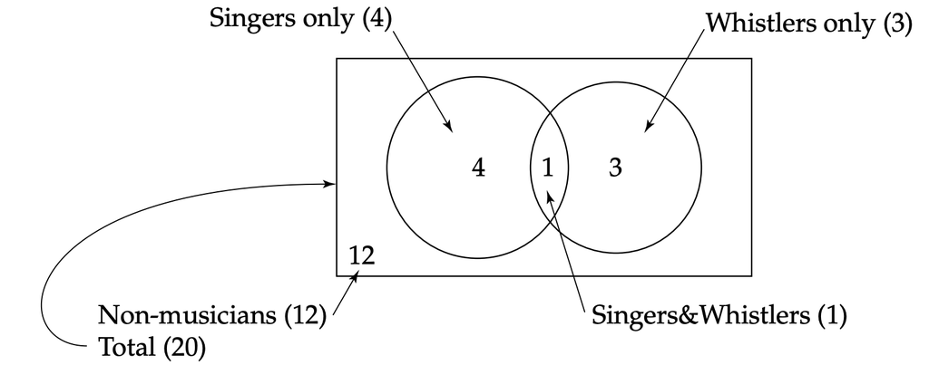

Normality? Certainty? Complementation? Additivity? Overlap? Conditional?

# Conditional Probability Quiz!

[figure not shown]

## Conditional Probability

# Marginal Probabilities

- The marginal probability of a variable is given by the area of the corresponding circle, independently fo the circles

# Conditional probability

$P(A|B) \neq P(B|A)$